# Project Song

Author: Justine Huynh

Date: 29 November 2020

## Problem

There are many factors that determine whether a song becomes very popular, or even becomes a major hit. But what are these factors? Which factors are considered the most pivotal in determining a song's popularity?

## Background

Most people have favorite songs or songs they prefer to listen to over others. Some people love music so much they have dedicated a musical database to songs.

Ultimate Music Database is a database that has an "(almost) complete database" of popular music. UMD shows top singles and top albums in multiple regions such as the UK, Luxembourg, etc for multiple years.

- For each specific region, ranks the top 100 songs each week

In this project, we will be looking at the top 100 songs in the UK.

# Methods I Considered Using

- Scrape just the UMD website using `Beautiful Soup` for the year 2020 from January to end of October
- Visualize some factors (artist, release date, etc) that determine song placement
- Given the song's name, artist, release date, etc for the month of November, determine each song's placement using a pipeline.
- Test which model is best: Gaussian Naive Bayes, K Nearest Neighbors, Decision Tree Regressor, Random Forest Regressor

### Slight Problem

- Not enough information about the characteristics of each song
- Songs are "sticky." New songs that are popular tend to have the same placement as the previous weeks -> time series data

# Methods I Actually Used

### Scraping Data

Classification: This project will see the factors that determine whether a song becomes a hit in the UK.

- `Beautiful Soup` to scrape the top 100 NEW songs who were a hit in UK from the data tables from the period start of 2019 to end of October 2020.
- These hit songs will be labeled with a variable `isHit = 1`.
- Album Of The Year (AOTY), that featured all the songs/albums that came out in 2020. I made sure to grab only the songs that were not included in UK's top 100 songs from 2019 to 2020.
- These songs were the songs who were not a hit in the UK, specifically `isHit = 0`.
- `Spotipy` API to scrape Spotify music. Specifically, search up all the audio features of the song as well as the artist, album, and release date.
- Taking all the information together, I formed one giant dataframe of all the songs and their characteristics, differentiable by whether they were listed at top 100 hits in the UK or not.

# Methods I Actually Used

### Data Visualization

- Used `plotnine` and `ggplot` (great visuals!) to visualize some factors that are indicators of a song's popularity and whether they became top hits in the UK when they first premiered.

# Methods I Actually Used

### Machine Learning

- Utilize a smooth, streamlined pipeline (can test many different parameters)
- Used stellar classification models: Gaussian Naive Bayes, K Nearest Neighbors, Decision Tree Classifiers, and Random Forest Classifier to predict whether a new song would become a hit in the UK

# Results

### Data Visualization

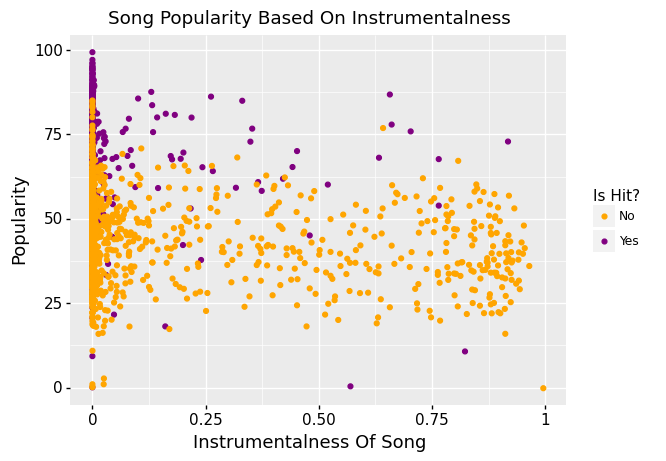

```python
(
    fullSongs >>
    select(X.instrumentalness, X.isHit, X.popularity) >>
    ggplot() +
    geom_point(aes(x = "instrumentalness", y = "popularity", color = "factor(isHit)"), position = "jitter") +
    labs(
        x = "Instrumentalness Of Song",
        y = "Popularity",
        title = "Song Popularity Based On Instrumentalness",
        color = "Is Hit?"
    ) +
    theme(axis_text = element_text(color = "black", size = 11)) +
    theme(axis_title = element_text(color = "black", size = 13)) +
    scale_color_manual(values = ["orange", "purple"],
                      labels = ["No", "Yes"])
)
```

```python
# fullSongs = pd.read_csv("fullSongs.csv")
```

## Machine Learning Results

4 models

1. Gaussian Naive Bayes
2. K Nearest Neighbors
3. Decision Tree Classifier
4. Random Forest Classifier (the chosen one)

Best parameters:

- Max depth: 9
- Number Of Estimators (Trees In Forest): 1500

Performance On Training Data

- AUC Score: 98.10%
- Accuracy: 98%

Performance On Testing Data

- AUC Score: 98%
- Accuracy: 88%

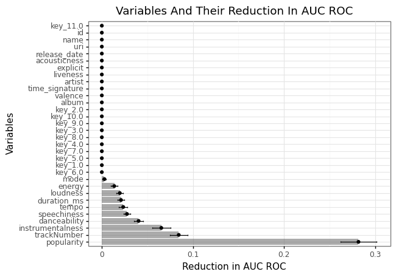

```python
# Plot Reduction In AUC curve
(
    ggplot(vi_dat,
          aes(x="variable", y="vi")) +
    geom_col(alpha=.5) +
    geom_point() +
    geom_errorbar(aes(ymin="low",ymax="high"),width=.2) +
    theme_bw() +
    scale_x_discrete(limits=vi_dat.variable.tolist()) +
    coord_flip() +
    labs(y="Reduction in AUC ROC",
         x= "Variables",
        title = "Variables And Their Reduction In AUC ROC")
)
```

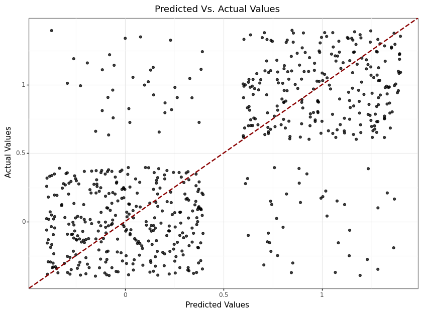

```python
(
    ggplot(pd.DataFrame(dict(pred=y_pred,truth=Y_test)),
          aes(x='pred',y="truth")) +
    geom_point(alpha=.75, position = "jitter") +
    geom_abline(linetype="dashed",color="darkred",size=1) +
    labs(
        x = "Predicted Values",
        y = "Actual Values",
        title = "Predicted Vs. Actual Values"
    ) +
    theme_bw() +
    theme(figure_size=(10,7))
)
```

# Lessons Learned

- Besides popularity, other factors that determined whether a song became a hit was track number, danceability, and instrumentalness.
- The more complex a tree/model is, the higher the accuracy on training data (be careful of overfitting)
- Reading API is sometimes difficult but helpful
- We need to find positive cases (isHit) and negative cases (isNotHit) for data

# Improvements

- Account for songs who had at least 2 artists or were collaborative
- Small artists who are featured can gain popularity and increase their song popularity

## Github

- https://github.com/jghuynh/Song_Shine